# Objetivo 4

Iván

2025-05-26

```r
library(dplyr)
library(stringr)
library(tibble)
library(readxl)
library(purrr)
library(writexl)
```

```r
library(ggplot2)
library(ggrepel)
library(scales)
```

## Explicación:

**OBJETIVO IV**: *Estimar un índice de contaminación por país y analizar el resto de sectores que no tienen relación directa con la huella ciudadana como las industrias o la agricultura*.

Construir una **fórmula** para estimar un **índice de contaminación por país**, a partir de los datos de calidad del aire de las ciudades principales ponderadas por su **densidad poblacional**. Este índice servirá para analizar diferencias entre países y explorar la contaminación atribuible a **sectores donde la ciudadanía no tiene acción directa**, como la agricultura extensiva o ciertas industrias pesadas, incorporando también **indicadores económicos nacionales** para analizar de mejor forma las diferencias entre sectores de diversos países.

Eurostat proporciona datos del PIB a precios de mercado actuales por regiones NUTS 2, así como herramientas para identificar la región correspondiente a cada ciudad europea. A partir de esta asociación, es posible asignar a cada ciudad un valor de PIB regional. Cuando no se dispone de datos urbanos específicos, se puede estimar el PIB de la ciudad en función de su peso poblacional dentro de la región NUTS 2, permitiendo así comparaciones coherentes.

### 1. Selección de sectores

Sectores no atribuibles directamente a la ciudadanía

Para el análisis de emisiones, se ha seleccionado un conjunto de sectores considerados como no atribuibles directamente al comportamiento individual o doméstico de la ciudadanía. Estos sectores incluyen actividades industriales, agrícolas, energéticas o institucionales, cuyas emisiones dependen principalmente de políticas públicas, estructuras económicas y procesos productivos a gran escala.

Los sectores considerados son los siguientes:

**Sector 1** **– Producción y transformación de energía:** Incluye las emisiones originadas en centrales térmicas, plantas de cogeneración, refinerías y otras instalaciones de generación energética. No se consideran aquí los consumos residenciales.

**Sector 2 – Industria manufacturera y construcción:** Abarca los procesos de combustión y consumo energético en la industria y la construcción, excluyendo el uso doméstico.

**Sector 4 – Procesos industriales y uso de productos:** Se refiere a emisiones no energéticas que provienen de transformaciones químicas en la producción de cemento, acero, fertilizantes, entre otros.

**Sector 7 – Transporte por carretera:** Incluye las emisiones del parque móvil terrestre, tanto privado como profesional (automóviles, camiones, autobuses), excluyendo la navegación y la aviación.

**Sector 8 – Otras fuentes móviles y maquinaria:** Considera la maquinaria agrícola, de construcción, trenes, barcos y aviones en tierra. Son emisiones vinculadas a medios de transporte no convencionales o no urbanos.

**Sector 9 – Gestión de residuos:** Comprende emisiones procedentes de vertederos, plantas de incineración, tratamiento de aguas residuales y compostaje.

**Sector 11 – Agricultura:** Incluye emisiones asociadas a prácticas agrícolas y ganaderas, como el uso de fertilizantes, la gestión de estiércol o la fermentación entérica del ganado.

**Sector 12 – Uso del suelo, cambio de uso del suelo y silvicultura:** Registra tanto emisiones como absorciones de carbono debidas a la deforestación, reforestación, cultivos o drenaje de humedales.

### 2. Integración y Agregación de Datos por Ciudad a Nivel NUTS 2

```r
# Archivos y lectura de datos
archivo_lau <- "EU-27-LAU-2024-NUTS-2024.xlsx"
archivo_gases <- "Gases.xlsx"
archivo_ranking <- "Ranking ciudades.xlsx"

hojas <- excel_sheets(archivo_lau)
hojas_paises <- hojas[!(hojas %in% c("File_info", "Overview", "Overview_Population"))]

ranking <- read_excel(archivo_ranking, sheet = "Ranking ciudades") %>%
  rename(CITY = CIUDAD, Poblacion = POBLACION) %>%
  mutate(CITY = str_trim(CITY))

gases <- read_excel(archivo_gases, sheet = "Ciudades_origen_gases") %>%
  rename(CITY = CIUDAD)

sectores_validos <- c(1, 2, 4, 7, 8, 9, 11, 12)

emisiones_filtradas <- gases %>%
  filter(SECTOR %in% sectores_validos) %>%
  group_by(CITY) %>%
  summarise(Emision_no_ciudad = sum(POTENCIAL, na.rm = TRUE), .groups = "drop")

#  Función por país con agrupación NUTS2
procesar_pais_nuts2 <- function(pais) {
  message("Procesando: ", pais)

  lau <- tryCatch(
    read_excel(archivo_lau, sheet = pais) %>%
      rename(
        CITY = `LAU NAME LATIN`,
        NUTS3 = `NUTS 3 CODE`,
        Area_m2 = `TOTAL AREA (m2)`
      ) %>%
      mutate(
        CITY = str_trim(CITY),
        Area_km2 = Area_m2 / 1e6
      ),
    error = function(e) return(NULL)
  )

  if (is.null(lau)) return(NULL)

  ciudades_nuts3 <- left_join(ranking, lau, by = "CITY") %>%
    mutate(NUTS2 = substr(NUTS3, 1, 4))

  datos_agrupados <- ciudades_nuts3 %>%
    group_by(NUTS2) %>%
    summarise(
      Poblacion_Urbana = sum(Poblacion, na.rm = TRUE),
      Area_Total_km2   = sum(Area_km2, na.rm = TRUE),
      Densidad_media   = Poblacion_Urbana / Area_Total_km2,
      .groups = "drop"
    )

  ciudades_emisiones <- left_join(ciudades_nuts3, emisiones_filtradas, by = "CITY")

  emisiones_agrupadas <- ciudades_emisiones %>%
    group_by(NUTS2) %>%
    summarise(
      Emision_no_ciudad = sum(Emision_no_ciudad, na.rm = TRUE),
      .groups = "drop"
    )

  resultado <- left_join(datos_agrupados, emisiones_agrupadas, by = "NUTS2") %>%
    mutate(Pais = pais)

  return(resultado)
}

# Aplicar a todos los países y mostrar resultado
resultados_nuts2 <- map_dfr(hojas_paises, procesar_pais_nuts2)
```

```
## Procesando: BE
```

```
## Procesando: BG
```

```
## Procesando: DK
```

```
## Procesando: DE
```

```
## Procesando: EE
```

```
## Procesando: IE
```

```
## Procesando: EL
```

```
## Procesando: CZ
```

```
## Procesando: ES
```

```
## Procesando: FR
```

```
## Procesando: HR
```

```
## Procesando: IT
```

```
## Procesando: CY
```

```
## Procesando: LV
```

```
## Procesando: LT
```

```
## Procesando: LU
```

```
## Procesando: HU
```

```
## Procesando: MT
```

```
## Procesando: NL
```

```
## Procesando: AT
```

```
## Procesando: PL
```

```
## Procesando: PT
```

```
## Procesando: RO
```

```
## Procesando: SI
```

```
## Procesando: SK
```

```
## Procesando: FI
```

```
## Procesando: SE
```

```
## Procesando: LI
```

```
## Procesando: NO
```

```
## Procesando: CH
```

```
## Procesando: MK
```

```
## Procesando: TR
```

```r
# Vista final
print(resultados_nuts2)
```

```
## # A tibble: 172 × 6
##    NUTS2 Poblacion_Urbana Area_Total_km2 Densidad_media Emision_no_ciudad Pais
##    <chr>            <dbl>          <dbl>          <dbl>             <dbl> <chr>
##  1 BE21           1489741          107.          13898.              50.8 BE
##  2 BE32            299236          251.           1195.             108.  BE
##  3 BE33            383700           68.7          5589.              54.8 BE
##  4 BE35            112125          176.            637.              56.8 BE
##  5 <NA>         141037406            0             Inf            14202.  BE
##  6 BG32            210059         1453.            145.              90.0 BG
##  7 BG33            336216          238.           1410.              44.2 BG
##  8 BG34            134726         1093.            123.              62.1 BG
##  9 BG41             72241          485.            149.               0   BG
## 10 BG42            347851          102.           3413.              35.6 BG
## # ℹ 162 more rows
```

En el código se procesan datos de ciudades europeas agrupándolos por regiones NUTS2. Primero, carga tres archivos Excel: uno con información geográfica (áreas y códigos NUTS), otro con datos de población urbana por ciudad, y otro con emisiones por sectores. Luego, selecciona las hojas correspondientes a países y define una función que, para cada uno, lee sus datos, los combina con la población y emisiones válidas (sectores 1, 2, 4, 7, 8, 9, 11 y 12), y calcula por cada región NUTS2 la población urbana total, el área total en km², la densidad poblacional media y las emisiones no ciudadanas. El resultado final es una tabla consolidada con todos los países, lista para análisis posteriores.

#### 2.1 Descarte de agrupación por NUTS 2

Las regiones NUTS 2 no tienen una homogeneidad territorial clara entre países. Por ejemplo:

- En España, NUTS 2 son las Comunidades Autónomas (Andalucía, Cataluña…)
- En Alemania, NUTS 2 incluye Regierungsbezirke o combinaciones de distritos, con tamaños muy desiguales.

Esto puede hacer que los datos agregados a NUTS 2 sean difíciles de comparar entre países, ya que representan realidades administrativas y poblacionales muy distintas.

**NUTS 1 ofrece mayor estabilidad y agregación útil**, para muchos análisis de tipo nacional, económico o ambiental, NUTS 1 proporciona una división más adecuada:

- Agrega el ruido estadístico presente a nivel de detalle más fino.
- Representa mejor regiones funcionales amplias, como “Este”, “Centro”, “Sur”..

### 3. Integración y Agregación de Datos por Ciudad a Nivel NUTS 1

Se procede a agrupar e integrar los datos procedentes de diferentes bases de datos utilizando como criterio de agregación el código NUTS 1, el cual permite una desagregación regiones dentro de cada país. Esta agregación se realiza de forma independiente para cada país, con el objetivo de evitar errores debidos a solapamientos o codificaciones inconsistentes entre regiones homónimas de distintos Estados.

Para cada ciudad, se identifican las unidades territoriales NUTS 1 correspondientes y se suman los valores asociados al potencial de emisión de gases atribuibles a sectores no ciudadanos (por ejemplo, sectores industriales, comerciales o de transporte de mercancías). Asimismo, se agregan los datos relativos a:

- Producto Interior Bruto (PIB)
- Población residente
- Área total (en km²)

```r
# Cargar datos
lau_nuts <- read_excel("EU-27-LAU-2024-NUTS-2024.xlsx", sheet = "ES")
gases     <- read_excel("Gases.xlsx", sheet = "Ciudades_origen_gases")
ranking   <- read_excel("Ranking ciudades.xlsx", sheet = "Ranking ciudades")

# Tabla de correspondencia NUTS1 ↔ Región
nuts1_to_region <- tribble(
  ~NUTS1, ~Region,
  "ES1", "Noroeste",
  "ES2", "Nordeste",
  "ES3", "Comunidad Madrid",
  "ES4", "Centro",
  "ES5", "Este",
  "ES6", "Sur",
  "ES7", "Canarias"  # Canarias como está
)

# Preparar nombres y área
lau_nuts <- lau_nuts %>%
  rename(
    CITY    = `LAU NAME LATIN`,
    NUTS3   = `NUTS 3 CODE`,
    Area_m2 = `TOTAL AREA (m2)`
  ) %>%
  mutate(
    CITY     = str_trim(CITY),
    Area_km2 = Area_m2 / 1e6
  )

ranking <- ranking %>%
  rename(
    CITY      = CIUDAD,
    Poblacion = POBLACION
  ) %>%
  mutate(CITY = str_trim(CITY))

# Unir ranking con área y NUTS3
ciudades_nuts3 <- left_join(ranking, lau_nuts, by = "CITY")

# Extraer NUTS1 y unir con nombre de región
ciudades_nuts3 <- ciudades_nuts3 %>%
  mutate(NUTS1 = substr(NUTS3, 1, 3)) %>%
  left_join(nuts1_to_region, by = "NUTS1")

# Agregaciones de población y área por NUTS1
datos_agrupados <- ciudades_nuts3 %>%
  group_by(NUTS1, Region) %>%
  summarise(
    Poblacion_Urbana = sum(Poblacion, na.rm = TRUE),
    Area_Total_km2   = sum(Area_km2,   na.rm = TRUE),
    Densidad_media   = Poblacion_Urbana / Area_Total_km2,
    .groups = "drop"
  )

# Emisiones por sectores no ciudadanos
sectores_validos <- c(1, 2, 4, 7, 8, 9, 11, 12)

emisiones_filtradas <- gases %>%
  filter(SECTOR %in% sectores_validos) %>%
  group_by(CIUDAD) %>%
  summarise(
    Emision_no_ciudad = sum(POTENCIAL, na.rm = TRUE),
    .groups = "drop"
  ) %>%
  rename(CITY = CIUDAD)

# Unir emisiones y extraer NUTS1
ciudades_emisiones <- left_join(ciudades_nuts3, emisiones_filtradas, by = "CITY")

# Emisiones agregadas por NUTS1
emisiones_agrupadas <- ciudades_emisiones %>%
  group_by(NUTS1, Region) %>%
  summarise(
    Emision_no_ciudad = sum(Emision_no_ciudad, na.rm = TRUE),
    .groups = "drop"
  )

# Combinar poblaciones y emisiones
resultado_final <- left_join(
  datos_agrupados,
  emisiones_agrupadas,
  by = c("NUTS1", "Region")
)

# Mostrar resultado
print(resultado_final)
```

```
## # A tibble: 8 × 6
##   NUTS1 Region  Poblacion_Urbana Area_Total_km2 Densidad_media Emision_no_ciudad
##   <chr> <chr>              <dbl>          <dbl>          <dbl>             <dbl>
## 1 ES1   Noroes…          1541912          1414.          1091.             480.
## 2 ES2   Nordes…          1631952          1094.          1491.             103.
## 3 ES3   Comuni…          5570780           817.          6820.              19.1
## 4 ES4   Centro           1187518          4367.           272.             284.
## 5 ES5   Este             4903638           751.          6529.             385.
## 6 ES6   Sur              3226503          3401.           949.             319.
## 7 ES7   Canari…           535541           275.          1947.               0
## 8 <NA>  <NA>           124724364             0            Inf            12882.
```

Podemos optimizarlo para todos los paises de esta forma:

```r
archivo_lau <- "EU-27-LAU-2024-NUTS-2024.xlsx"
archivo_gases <- "Gases.xlsx"
archivo_ranking <- "Ranking ciudades.xlsx"

# Leer todas las hojas (nombres de países)
hojas <- excel_sheets(archivo_lau)
hojas_paises <- hojas[!(hojas %in% c("File_info", "Overview", "Overview_Population"))]

# Cargar datos auxiliares
ranking <- read_excel(archivo_ranking, sheet = "Ranking ciudades") %>%
  rename(CITY = CIUDAD, Poblacion = POBLACION) %>%
  mutate(CITY = str_trim(CITY))

gases <- read_excel(archivo_gases, sheet = "Ciudades_origen_gases") %>%
  rename(CITY = CIUDAD)

sectores_validos <- c(1, 2, 4, 7, 8, 9, 11, 12)

emisiones_filtradas <- gases %>%
  filter(SECTOR %in% sectores_validos) %>%
  group_by(CITY) %>%
  summarise(Emision_no_ciudad = sum(POTENCIAL, na.rm = TRUE), .groups = "drop")

# Función de procesamiento por país
procesar_pais <- function(pais) {
  message("Procesando: ", pais)

  lau <- tryCatch(
    read_excel(archivo_lau, sheet = pais) %>%
      rename(
        CITY = `LAU NAME LATIN`,
        NUTS3 = `NUTS 3 CODE`,
        Area_m2 = `TOTAL AREA (m2)`
      ) %>%
      mutate(
        CITY = str_trim(CITY),
        Area_km2 = Area_m2 / 1e6
      ),
    error = function(e) return(NULL)
  )

  if (is.null(lau)) return(NULL)

  ciudades_nuts3 <- left_join(ranking, lau, by = "CITY") %>%
    mutate(NUTS1 = substr(NUTS3, 1, 3))

  datos_agrupados <- ciudades_nuts3 %>%
    group_by(NUTS1) %>%
    summarise(
      Poblacion_Urbana = sum(Poblacion, na.rm = TRUE),
      Area_Total_km2 = sum(Area_km2, na.rm = TRUE),
      Densidad_media = Poblacion_Urbana / Area_Total_km2,
      .groups = "drop"
    )

  ciudades_emisiones <- left_join(ciudades_nuts3, emisiones_filtradas, by = "CITY")

  emisiones_agrupadas <- ciudades_emisiones %>%
    group_by(NUTS1) %>%
    summarise(Emision_no_ciudad = sum(Emision_no_ciudad, na.rm = TRUE), .groups = "drop")

  resultado <- left_join(datos_agrupados, emisiones_agrupadas, by = "NUTS1") %>%
    mutate(Pais = pais)

  return(resultado)
}

resultados_todos <- map_dfr(hojas_paises, procesar_pais)
```

```
## Procesando: BE
```

```
## Procesando: BG
```

```
## Procesando: DK
```

```
## Procesando: DE
```

```
## Procesando: EE
```

```
## Procesando: IE
```

```
## Procesando: EL
```

```
## Procesando: CZ
```

```
## Procesando: ES
```

```
## Procesando: FR
```

```
## Procesando: HR
```

```
## Procesando: IT
```

```
## Procesando: CY
```

```
## Procesando: LV
```

```
## Procesando: LT
```

```
## Procesando: LU
```

```
## Procesando: HU
```

```
## Procesando: MT
```

```
## Procesando: NL
```

```
## Procesando: AT
```

```
## Procesando: PL
```

```
## Procesando: PT
```

```
## Procesando: RO
```

```
## Procesando: SI
```

```
## Procesando: SK
```

```
## Procesando: FI
```

```
## Procesando: SE
```

```
## Procesando: LI
```

```
## Procesando: NO
```

```
## Procesando: CH
```

```
## Procesando: MK
```

```
## Procesando: TR
```

```r
print(resultados_todos)
```

```
## # A tibble: 100 × 6
##    NUTS1 Poblacion_Urbana Area_Total_km2 Densidad_media Emision_no_ciudad Pais
##    <chr>            <dbl>          <dbl>          <dbl>             <dbl> <chr>
##  1 BE2            1489741        107.            13898.              50.8 BE
##  2 BE3             795061        495.             1606.             220.  BE
##  3 <NA>         141037406          0               Inf            14202.  BE
##  4 BG3             681001       2784.              245.             196.  BG
##  5 BG4             420092        587.              716.              35.6 BG
##  6 <NA>         142221115          0               Inf            14241.  BG
##  7 DK0             762888       1227.              622.             107.  DK
##  8 <NA>         142559320          0               Inf            14366.  DK
##  9 DE2            2623328         92.6           28342.             468.  DE
## 10 DE4              95653          0.671        142553.              68.8 DE
## # ℹ 90 more rows
```

En la siguiente tabla, aparecen los países que no están agrupados por NUTS 1 porque solo tienen una región NUTS 2 en la base de datos. Esto implica que no es posible hacer una agregación territorial adicional para esos países a nivel NUTS 1.

```r
# Leer datos desde la hoja correspondiente
df <- read_excel("Pasies_comunidad.xlsx", sheet = "Anexar1")

# Extraer código NUTS1 (primeros 3 caracteres de NUTS2)
df <- df %>%
  mutate(NUTS1 = substr(NUTS2, 1, 3))

# Calcular número de regiones NUTS2 y NUTS1 por país
df_nuts_check <- df %>%
  group_by(Pais_Nombre) %>%
  summarise(
    Num_NUTS1 = n_distinct(NUTS1),
    Num_NUTS2 = n_distinct(NUTS2)
  )

# Filtrar países que no tienen subdivisiones NUTS2 (solo una región)
df_no_agrupables <- df_nuts_check %>%
  filter(Num_NUTS2 == 1)

# Mostrar la tabla final
print(df_no_agrupables)
```

```
## # A tibble: 10 × 3
##    Pais_Nombre         Num_NUTS1 Num_NUTS2
##    <chr>                   <int>     <int>
##  1 Albania                     1         1
##  2 Chipre                      1         1
##  3 Estonia                     1         1
##  4 Kosovo                      1         1
##  5 Letonia                     1         1
##  6 Lituania                    1         1
##  7 Luxemburgo                  1         1
##  8 Macedonia del Norte         1         1
##  9 Moldavia                    1         1
## 10 Montenegro                  1         1
```

### 4. Índice por NUT1

Para comparar de forma justa el impacto de la contaminación entre regiones, proponemos el siguiente índice:

$$\text{Índice}_r = \left( \frac{E_r}{\text{Área}_r} \right) \cdot \left(
\frac{D_r}{\overline{D}} \right) \cdot \left(
\frac{\overline{\text{PIB}}}{\text{PIB}_r} \right)$$

donde:

- $E_r$: emisiones totales de la región $r$
- $\text{Área}_r$: área total (en km²) de la región $r$
- $D_r$: densidad poblacional de la región $r$ (habitantes/km²)
- $\text{PIB}_r$: Producto Interior Bruto de la región $r$
- $\overline{D}$: densidad media de todas las regiones
- $\overline{\text{PIB}}$: PIB medio de todas las regiones

```r
# Cargar los datos
reg <- read_excel("Pasies_comunidad.xlsx")

# Calcular medias necesarias
media_densidad <- mean(reg$Densidad_media, na.rm = TRUE)
media_pib      <- mean(reg$PIB_mill_euros, na.rm = TRUE)

# Calcular índice de contaminación
reg <- reg %>%
  mutate(
    Intensidad_Emision   = Emisiones_no_ciudad / Area_Total_km2,
    Factor_Densidad      = Densidad_media / media_densidad,
    Factor_PIB           = media_pib / PIB_mill_euros,
    Indice_Contaminacion = Intensidad_Emision * Factor_Densidad * Factor_PIB
  )

# Guardar en un nuevo archivo Excel
write_xlsx(reg, "Pasies_comunidad_con_indice.xlsx")
print(reg)
```

```
## # A tibble: 181 × 12
##    NUTS2 Nombre_Region          Poblacion_Urbana Area_Total_km2 Densidad_media
##    <chr> <chr>                             <dbl>          <dbl>          <dbl>
##  1 AL01  Shqipëria                       1640000        287480           570
##  2 DE1   Baden-Württemberg               4800000        170467          5657
##  3 DE2   Bayern                          4400000           177.         2483
##  4 DE6   Hamburg                         1800000          7553            23.8
##  5 DE8   Mecklenburg-Vorpommern          1600000        231923           689
##  6 DEB   Nordrhein-Westfalen             3200000         73649          4346
##  7 DE9   Niedersachsen                   2700000        145501          1856
##  8 DE94  Weser-Ems                       2700000        145501          1856
##  9 AM01  Yerevan                         1100000          2230         49327
## 10 AM02  Rest of Armenia                 1400000        276470           507
## # ℹ 171 more rows
## # ℹ 7 more variables: Emisiones_no_ciudad <dbl>, PIB_mill_euros <dbl>,
## #   Pais_Nombre <chr>, Intensidad_Emision <dbl>, Factor_Densidad <dbl>,
## #   Factor_PIB <dbl>, Indice_Contaminacion <dbl>
```

### 5. Índice por paises

**Definiciones y notación**

- $i$: índice del país.
- $j$: índice de ciudad dentro del país $i$.
- $C_{ij}$: nivel de contaminación en la ciudad $j$ (por ejemplo, concentración de PM2.5 o un índice compuesto).
- $D_{ij}$: densidad poblacional de la ciudad $j$ (habitantes/km²).
- $w_{ij}$: peso relativo de la ciudad $j$ en el país $i$, basado en su densidad poblacional:

$$w_{ij} = \frac{D_{ij}}{\sum_{j \in i} D_{ij}}$$

- $S_i^{\text{ciudad.}}$: suma de emisiones de los sectores **no atribuibles a la ciudadanía** en el país $i$, incluyendo los sectores:

$$S = \{1, 2, 4, 7, 8, 9, 11, 12\}$$

- $\text{PIB}_i$: Producto Interior Bruto del país $i$.

**Fórmula del índice compuesto**

**Interpretación de cada componente**

- $\sum w_{ij} \cdot C_{ij}$: exposición media urbana ponderada por densidad poblacional (ciudades más densas tienen más peso).
- $\frac{S_i^{\text{ciudad.}}}{\text{PIB}_i}$: intensidad estructural de emisiones, normalizada respecto al nivel de riqueza nacional.

```r
# 1. Leer datos
df <- read_excel("Pasies_comunidad.xlsx")

# 2. Normalizar Densidad y PIB a rango [0,1]
df_norm <- df %>%
  mutate(
    dens_norm = (Densidad_media - min(Densidad_media, na.rm = TRUE)) /
                (max(Densidad_media, na.rm = TRUE) - min(Densidad_media, na.rm = TRUE)),
    pib_norm  = (PIB_mill_euros - min(PIB_mill_euros,       na.rm = TRUE)) /
                (max(PIB_mill_euros, na.rm = TRUE) - min(PIB_mill_euros, na.rm = TRUE))
  )

# 3. Índice de contaminación (media de las dos normalizadas)
df_norm <- df_norm %>%
  mutate(indice_contaminacion = (dens_norm + pib_norm) / 2)

# 4. Agregar por país
indice_por_pais <- df_norm %>%
  group_by(Pais_Nombre) %>%
  summarise(
    n_comunidades    = n(),
    indice_medio     = mean(indice_contaminacion, na.rm = TRUE),
    indice_suma      = sum(indice_contaminacion,  na.rm = TRUE)
  ) %>%
  arrange(desc(indice_medio))

print(indice_por_pais)
```

```
## # A tibble: 43 × 4
##    Pais_Nombre n_comunidades indice_medio indice_suma
##    <chr>               <int>        <dbl>       <dbl>
##  1 Rusia                   5       0.317        1.59
##  2 Portugal                5       0.208        1.04
##  3 Francia                 5       0.179        0.715
##  4 Armenia                 2       0.174        0.347
##  5 Alemania                7       0.169        1.18
##  6 Bélgica                 5       0.157        0.785
##  7 Reino Unido             5       0.154        0.768
##  8 Ucrania                 5       0.107        0.534
##  9 Italia                  7       0.101        0.705
## 10 Suecia                  5       0.0936       0.468
## # ℹ 33 more rows
```

Este índice podrá ser usado en caso de que se quiera realizar una comparativa intra-paises, sin embargo se opta por la opcion de la divisiones de los países en reigones NUTS1 para posteriores analisis en el hito 5. Ya que ofrencen una mejor visualización y aportan granularidad al informe.

### 6. PCA

A continuación se presenta un análisis de Componentes Principales (PCA) con el objetivo de **validar la estructura del índice de contaminación** propuesto y extraer información adicional sobre las relaciones entre las variables utilizadas.

```r
# 1. Cargar librerías
library(readxl)
library(FactoMineR)
library(factoextra)
```

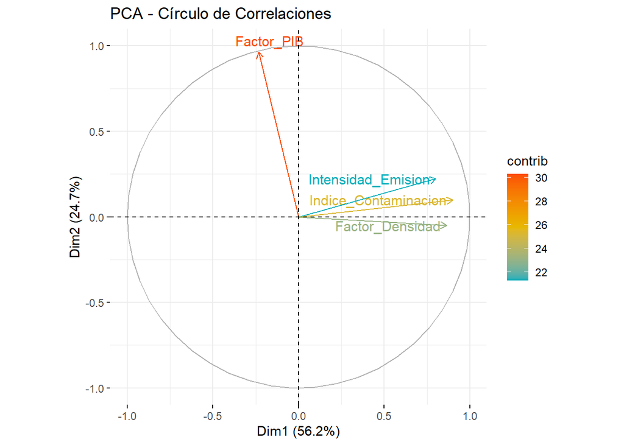

```r
# 2. Leer datos
df <- read_excel("Pasies_comunidad_con_indice_.xlsx")

# 3. Seleccionar variables numéricas para PCA
df_pca <- df %>%
  dplyr::select(Intensidad_Emision, Factor_Densidad, Factor_PIB, Indice_Contaminacion) %>%
  na.omit()

# 4. Realizar PCA
res.pca <- PCA(df_pca, scale.unit = TRUE, graph = FALSE)

# 5. Visualización de variables (círculo de correlaciones)
fviz_pca_var(res.pca,
             col.var = "contrib", # color por contribución al eje
             gradient.cols = c("#00AFBB", "#E7B800", "#FC4E07"),
             repel = TRUE, title = "PCA - Círculo de Correlaciones")
```

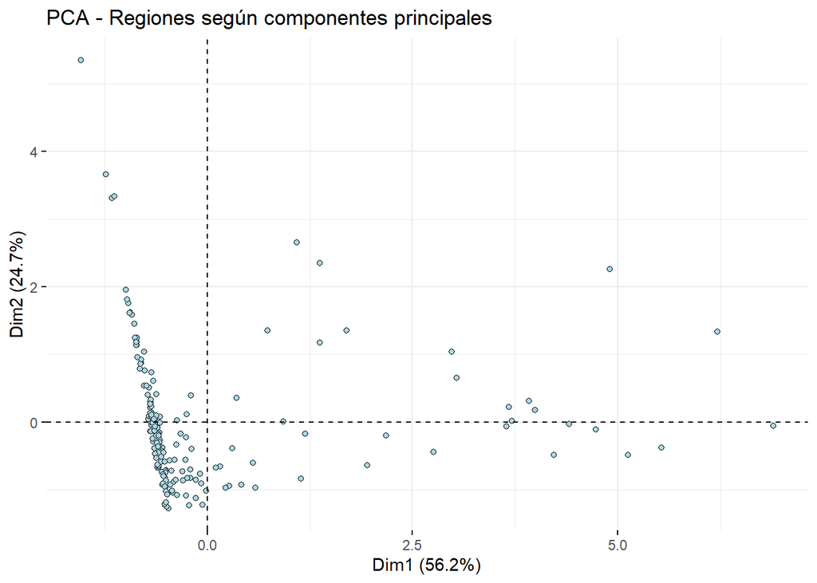

```r
# 6. Visualización de individuos (regiones)
fviz_pca_ind(res.pca,
             geom.ind = "point",
             pointshape = 21,
             fill.ind = "lightblue",
             col.ind = "black",
             repel = TRUE,
             title = "PCA - Regiones según componentes principales")
```

Desde un punto de vista estructural, el índice de contaminación muestra una fuerte alineación con la **intensidad de emisiones** y el **factor de densidad poblacional**, lo que confirma que representa adecuadamente estas dos dimensiones clave. Por otro lado, el **factor PIB** aparece ortogonal (perpendicular) a las anteriores, lo cual indica que aporta una dimensión independiente no correlacionada linealmente, reforzando la decisión metodológica de **multiplicar los factores en lugar de sumarlos**.

### 7. Representación del índice:

A continuación se representa visualmente el índice de contaminación en función de las principales variables estructurales que lo componen: el **PIB regional** (en escala logarítmica) y la **densidad de población**. Esta visualización permite identificar patrones espaciales y económicos en los niveles de contaminación, destacando aquellas regiones que presentan valores especialmente altos.

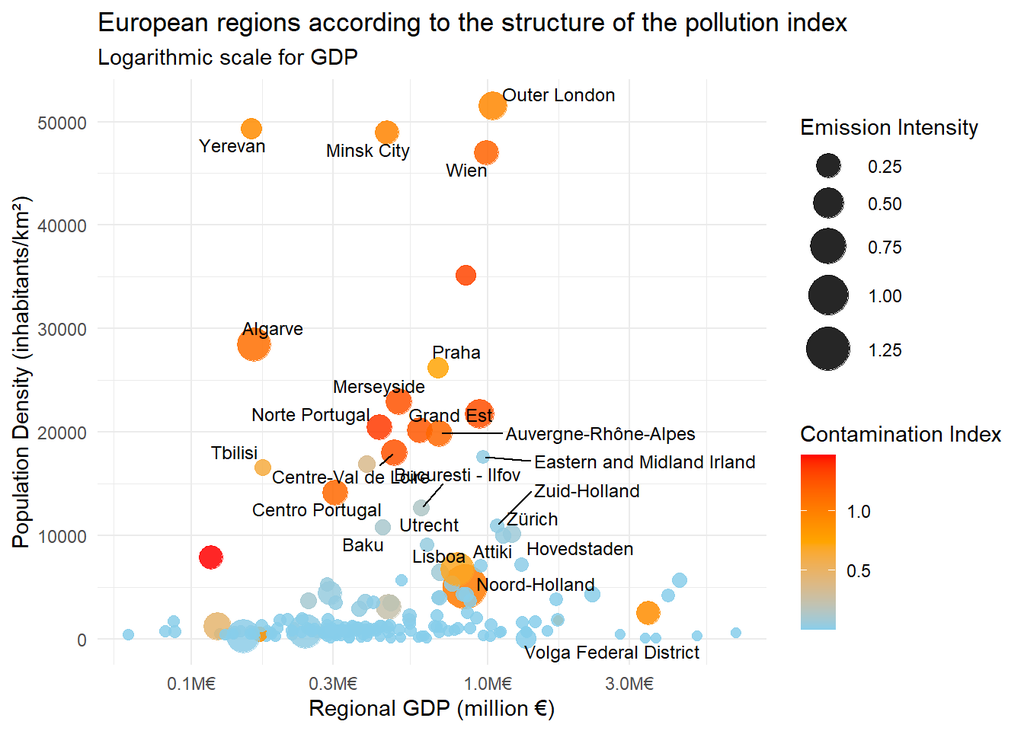

```r
# 1. Cargar datos
df <- read_excel("Pasies_comunidad_con_indice_.xlsx") %>%
  filter(!is.na(Indice_Contaminacion)) %>%
  mutate(
    Etiqueta = ifelse(Indice_Contaminacion > quantile(Indice_Contaminacion), Nombre_Region, NA)
  )

# 2. Calcular cuantiles para rescalar la paleta de color
lim_inf <- quantile(df$Indice_Contaminacion, 0.05, na.rm = TRUE)
lim_sup <- quantile(df$Indice_Contaminacion, 0.95, na.rm = TRUE)

# 3. Crear gráfico
ggplot(df, aes(x = PIB_mill_euros, y = Densidad_media)) +
  geom_point(aes(size = Intensidad_Emision, color = Indice_Contaminacion), alpha = 0.85) +
  scale_x_log10(labels = scales::comma_format(scale = 1e-6, suffix = "M€")) +
  scale_color_gradientn(
    colors = c("skyblue", "orange", "red"),
    values = rescale(c(lim_inf, lim_sup)),
    limits = c(min(df$Indice_Contaminacion), max(df$Indice_Contaminacion)),
    name = "Contamination Index"
  ) +
  scale_size_continuous(range = c(2, 10)) +
  geom_text_repel(aes(label = Etiqueta), size = 3.2, max.overlaps = 10) +
  theme_minimal() +
  labs(
    title = "European regions according to the structure of the pollution index",
    subtitle = "Logarithmic scale for GDP",
    x = "Regional GDP (million €)",
    y = "Population Density (inhabitants/km²)",
    size = "Emission Intensity"
  )
```

#### 7.2. **Dimensiones del problema**

Se observan dos ejes explicativos:

- **Dimensión socioeconómica (eje X)**: Las regiones con **bajo PIB** tienden a presentar niveles más altos de contaminación relativa, en consonancia con lo observado en el PCA (el factor PIB tiene un efecto de “compensación”). Esta relación sugiere que, aunque un PIB más elevado suele asociarse a una mayor actividad económica, también está correlacionado con **una mayor capacidad tecnológica y de inversión en infraestructuras menos contaminantes**.
- **Dimensión poblacional (eje Y)**: La **densidad de población** es un factor amplificador clave. A igualdad de emisiones, una mayor densidad implica mayor presión ambiental y mayor exposición de la población, como se refleja claramente en la ubicación vertical de las regiones más problemáticas.

#### 7.3. **Grupos diferenciados de regiones**

El gráfico permite distinguir al menos **tres grupos de comportamiento**:

- Regiones con **bajo PIB y alta densidad**, donde el índice es muy elevado.
- Regiones con **PIB elevado y densidad moderada**, donde el índice se mantiene bajo gracias a un mayor equilibrio estructural.
- Regiones con **bajo PIB y baja densidad**, que muestran índices bajos principalmente por dispersión territorial.